# Models for the Human Sex Ratio

## Background

- Over the next several lectures, we will explore a collection of data sets on the composition of boys and girls in families.

> Human gender identity is a complex issue. The `sex` variable identified as boy or girl in these data sets refer to the sex that is recorded at birth according to the appearance of genitalia. This sex measurement might not agree with the gender (binary or not) that an individual identifies with later in life.
- There are multiple theories about factors that might affect sex determination in humans.
- In many human populations, the observed relative frequency of male birth is slightly higher than 50 percent, and it is seen to fluctuate over time.
- A question we will investigate is:

> do all live births have the same probability of being male, or are some couples more likely than others to produce male (or female) children?
- There are very rare cases where an individual is born with both male and female genitalia and and also rare cases where an individual may have neither, or that the development of genitalia may occur later in life than is normal.
- Less rare, but uncommon are instances of multiple births (twins, triplets, and so on).
- In the data sets we will consider, such cases have been excluded.

## Data

- The first data set is a subset from a massive data collection made by Geissler and published in 1889 from church birth records in Saxony (in modern times a region in eastern Germany) during 1876–1885.
- During this time, each birth certificate was required to contain all of the children in the family.
- As a consequence, many families will appear multiple times in the data set if they had multiple children during this period, and many births are recorded multiple times (when they happened, and when younger siblings were born).
- However, all records from a given family size will correspond to separate families.
- The data we have for each family size actually shows results of the sexes among the first $k-1$ kids at the time of the birth of the $k$th kid.
- The reason for this weird choice is to lessen the presumed bias due to the decision to stop having more children based on the sex of the last child.
- This, however, ignores that same decision being made at the birth of the previous child.
- But it is the data that we have.

```r
geissler = read_csv("../../data/geissler.csv")

head(geissler)
```

```
## # A tibble: 6 x 4
##    boys girls  size   freq
##   <dbl> <dbl> <dbl>  <dbl>
## 1     0     1     1 108719
## 2     0     2     2  42860
## 3     0     3     3  17395
## 4     0     4     4   7004
## 5     0     5     5   2839
## 6     0     6     6   1096
```

- `boys` is the number of boys in the family
- `girls` is the number of girls in the family
- `size` equals `boys` plus `girls` and is the number of children in the family
- `freq` is the number of families with a birth certificate with this number of boys and girls who are older siblings to the child who was born.

## Initial Statistical Model

- We will begin by assuming a binomial model for $X$, the number of boys among the the first $n$ children in a Saxon family from this time period which has $n+1$ or more children.
- Let $p$ represent this probability.

$$X \,\mid\,p \sim \text{Binomial}(n,p)$$

- We will examine such a model a family size 8 in the data set, but the sae analysis can be repeated for other family sizes.
- I recommend doing a similar analysis for a different family size.

## Analysis

```r
### 1 Create a subset of the data including only families of a given size

g8 = geissler %>%
  filter(size==8)

### 2 Calculate the observed proportions of the number of families with each possible number of boys and girls. Add these proportions as a column to your data.

g8 = g8 %>%
  mutate(prop = freq/sum(freq))

### 3 Determine the total number of boys, the total number of girls, and the total number of children in your families. Estimate `p` by the ratio of the total number of boys out of the total number of children.

g8_sum = g8 %>%
  summarize(
    boys = sum(boys*freq),
    girls = sum(girls*freq),
    total = sum(size*freq),
    p_boy = boys/total,
    p_girl = girls/total
  )

g8_sum
```

```
## # A tibble: 1 x 5
##     boys  girls  total p_boy p_girl
##    <dbl>  <dbl>  <dbl> <dbl>  <dbl>
## 1 158790 149170 307960 0.516  0.484
```

```r
### 4 For this family size, assume the binomial distribution for the number of boys in a family of that size. Calculate the binomial probabilities of each possible outcome and add these values as a new column in your data frame.

p_8 = g8_sum$p_boy

p_8
```

```
## [1] 0.5156189
```

```r
g8 = g8 %>%
  mutate(p_binom = dbinom(0:8,8,p_8))

g8
```

```
## # A tibble: 9 x 6
##    boys girls  size  freq    prop p_binom
##   <dbl> <dbl> <dbl> <dbl>   <dbl>   <dbl>
## 1     0     8     8   161 0.00418 0.00303
## 2     1     7     8  1152 0.0299  0.0258
## 3     2     6     8  3951 0.103   0.0961
## 4     3     5     8  7603 0.198   0.205
## 5     4     4     8 10263 0.267   0.272
## 6     5     3     8  8498 0.221   0.232
## 7     6     2     8  4948 0.129   0.123
## 8     7     1     8  1655 0.0430  0.0375
## 9     8     0     8   264 0.00686 0.00500
```

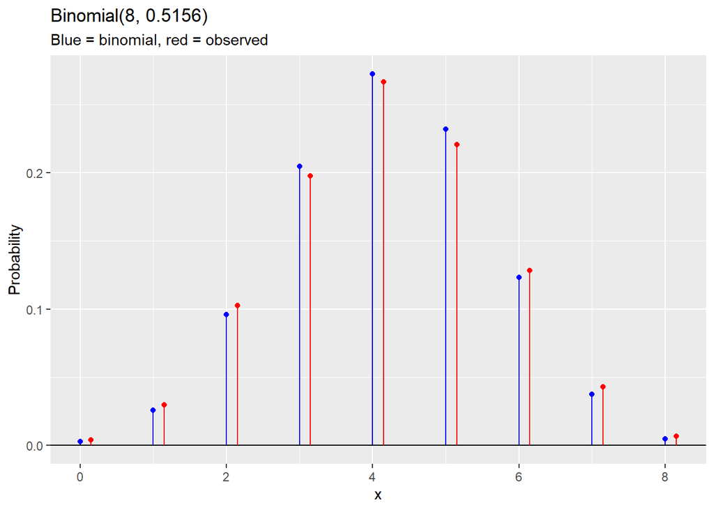

```r
### 5 Graph the binomial distribution (use `gbinom()`)

### 6 Add to this plot a graph of the observed frequencies with a line plot (geom_lines()). How do the observed frequencies compare to the binomial probabilities?

shift = 0.15
gbinom(8,round(p_8,4)) +
  geom_point(aes(x=boys,y=p_binom), data=g8, color="blue",shape=16) +
  geom_point(aes(x=boys+shift,y=prop), data=g8, color="red",shape=16) +
  geom_segment(aes(x = boys + shift, y = prop,
                   xend = boys + shift, yend = 0),
               data = g8, color = "red") +
  ggtitle("Binomial(8, 0.5156)",
          subtitle = "Blue = binomial, red = observed")
```

### Observations

- The observed proportions are slightly lower in the middle and higher in the tails than the binomial distribution.
- The true distribution is *overdispersed* relative to the binomial distribution.

```r
## Binomial variance
sigma2_binom = 8 * p_8 * (1-p_8)
sigma2_empirical = g8 %>%
  summarize(mu = sum(boys*freq)/sum(freq),
            sigma2 = sum( (boys - mu)^2 * freq ) / sum(freq) ) %>%
  pull(sigma2)

## variances
sigma2_binom
```

```
## [1] 1.998048
```

```r
sigma2_empirical
```

```
## [1] 2.160254
```

```r
## standard deviations
sqrt(sigma2_binom)
```

```
## [1] 1.413523
```

```r
sqrt(sigma2_empirical)
```

```
## [1] 1.46978
```

### Assumptions

The binomial model makes four key assumptions. What are they? (Recall BINS).

1. Binary outcomes for each trial (boy or girl)
2. Independence (genders of early trials do not affect subsequent ones)
3. Fixed sample size (families decide how many kids to hve before seeing genders of the earlier born kids)
4. Same probability (same probability of a boy for each child)

List potential realities that could violate these assumptions in the family composition data.

1. Maybe trials are not independent within families?
2. Could the chance of having a boy increase with the mother or father’s age?
3. Could different families have different chances of having male or female children?
4. Might families decisions to have more children be affected the number of children they already and how many are boys and girls?